# Class 25: Web scraping

Plan for today:

- Review of object-oriented programming
- Web scraping

```python
import YData

# YData.download.download_class_code(25)   # get class code
# YData.download.download_class_code(25, TRUE) # get the code with the answers
```

If you are using colabs, you should run the code below.

```python
# !pip install https://github.com/emeyers/YData_package/tarball/master
# from google.colab import drive
# drive.mount('/content/drive')
```

```python
import pandas as pd
import numpy as np
import seaborn as sns
import plotly.express as px
from urllib.request import urlopen

import matplotlib.pyplot as plt
%matplotlib inline

# Suppress ConvergenceWarning - please ignore this code
import warnings
warnings.filterwarnings("ignore", category=FutureWarning)
```

## 1. Review of object-oriented programming

[Object-oriented programming (OOP)](https://en.wikipedia.org/wiki/Object-oriented_programming) is a programming paradigm based on the concept of objects, which can contain data and code: data in the form of fields (often known as attributes or properties), and code in the form of procedures (often known as methods). In OOP, computer programs are designed by making them out of objects that interact with one another.

### Object constructor

Let's create a pretty boring object called `StorageObj` which will just store several different values. We will then add some methods to manipulate these values.

To start, let's write the "constructor" code that can be used to create a new `StorageObj` object.

```python
class StorageObj:

    # Constructor
    def __init__(self, a_string = "Hello", a_number = 42):

        # store the input arguments and some other default values
        self.s = a_string
        self.n = a_number
        self.b = True
        self.d = {"a":2, "b":7}
```

```python
# Create a new instance of a StorageObj object

my_obj = StorageObj("ok",3)

# print out the values in different fields

print(my_obj.n)
```

```
3
```

### Adding a method

Let's now add a method to our `StorageObj` called `.multiply_number(mult_val)` which will multiply the value stored in the field `.n` by the value `mult_val`.

```python
class StorageObj:

    # Constructor
    def __init__(self, a_string = "Hello", a_number = 42):

        # store the input arguments and some other default values
        self.s = a_string
        self.n = a_number
        self.b = True
        self.d = {"a":2, "b":7}

    def multiply_number(self,mult_val=7):
        return self.n * mult_val
    # The multiply_number method
```

```python
# try out our object

my_obj3 = StorageObj("I hope you're doing better soon",3)

my_obj3.multiply_number()
```

```
21
```

## 2. Widgets

We can add interactive "widgets" (i.e., buttons, slides, checkboxes, etc.) to a Jupyter notebook which let us explore our data.

Let's examine this now...

### Slider

```python
import ipywidgets as widgets
from IPython.display import display
```

```python
# Create a slider

slider = widgets.IntSlider(value = 10, min = 1, max = 20, step = 1)

slider
```

```
IntSlider(value=10, max=20, min=1)
```

```python
# Get the value of the slider

slider.value
```

```
17
```

### Button

```python
# Create a button

button = widgets.Button(description = "Touch Me")
# Create an output widget

output = widgets.Output()
# Define a function to be called when the button is clicked

def on_button_clicked(b):
    with output:
        print("Button Touched ;)")

# Attach the function to the button's on_click event

button.on_click(on_button_clicked)

# Display the button and output widget

display(button, output)
```

```
Button(description='Touch Me', style=ButtonStyle())
```

```
Output()
```

### Updating a figure

We can use a widget to update a figure.

This example is from: https://www.youtube.com/watch?v=wb6k_T4rKBQ&t=3s

```
interactive(children=(FloatSlider(value=1.0, description='bw', max=3.0, min=0.1), Checkbox(value=False, descri…
```

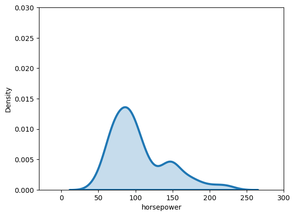

```python
cars = sns.load_dataset("mpg")

def bandwith_widget(bw = 1, filled = False):
    sns.kdeplot(cars.horsepower, lw = 3, fill = filled, bw_adjust = bw)
    plt.xlim(-30, 300)
    plt.ylim(0, 0.03)


widgets.interact(bandwith_widget, bw = (.1,3))

button_fill = widgets.Button(description = "Change Fill")

button.on_click(bandwith_widget(filled=True))
```

```python
# If we instead make the function argument a Boolean, a checkbox widget is added


def bandwith_widget(bw, my_fill = True):
    sns.kdeplot(cars.horsepower, lw = 3, fill = my_fill, bw_adjust = bw)
    plt.xlim(-30, 300)
    plt.ylim(0, 0.03)


widgets.interact(bandwith_widget, bw = (.1,3),my_fill = True);
```

```
interactive(children=(FloatSlider(value=1.55, description='bw', max=3.0, min=0.1), Checkbox(value=True, descri…
```

```python
# Another way to do this

@widgets.interact(bw=(.1,3))
def bandwidth_widget(bw=1):
    sns.kdeplot(cars.horsepower, lw = 3, fill = True, bw_adjust = bw)
    plt.xlim(-30, 300)
    plt.ylim(0, 0.03)
```

```
interactive(children=(FloatSlider(value=1.0, description='bw', max=3.0, min=0.1), Output()), _dom_classes=('wi…
```

```python
# Another example
#@widgets.interact_manual(color=['blue', 'red', 'green'], lw=(1., 10.))
@widgets.interact(color=['blue', 'red', 'green'], lw=(1., 10.))
def plot(freq=1., color='blue', lw=2, grid=True, title = "Sine wave"):
    t = np.linspace(-1., +1., 1000)
    fig, ax = plt.subplots(1, 1, figsize=(8, 6))
    ax.plot(t, np.sin(2 * np.pi * freq * t),
            lw=lw, color=color)
    ax.set_title(title)
    ax.grid(grid)
```

```
interactive(children=(FloatSlider(value=1.0, description='freq', max=3.0, min=-1.0), Dropdown(description='col…
```

## 3. Saving Jupyter notebooks as websites

If we save our Jupyter notebooks as .html documents (as you have done on the homework before printing them to pdfs) we can upload the .html documents to GitHub and view them as webpages on the Internet. This can be useful to show off your work to others (e.g., potential employers, etc.).

We can create a website to show off our work by completing the following instructions:

1. Create an account on GitHub.com
2. Create new repo. Call the repo "YData_website" or a similar name
3. Click on Settings (top right below the repo name). Click on "Pages" on the left menu (at the bottom of "Code and automation section)
4. Select the Branch to be "main"
5. Upload an html document to the main GitHub repository; e.g., upload a webpage called "simple_page.html"
6. Website is available at: [https://[username].github.io/[repo_name]/simple_page.html](https://%5Busername%5D.github.io/%5Brepo_name%5D/simple_page.html) (where "repo_name" is the repo name from step 2)

You can also create interactive notebooks by uploading jupyter .ipynb files to the GitHub site and then using https://mybinder.org/ to render them.

```python
import plotly.express as px
import plotly
plotly.offline.init_notebook_mode()  # allows interactive graphics to work when saved as a hmtl document


# Create some interactive graphics to make this into an interesting webpage
gapminder = px.data.gapminder()   # the plotly package comes with the gapminder data
gapminder_2007 = gapminder[gapminder['year'] == 2007]
gapminder_2007_alt = gapminder.query("year==2007")
gapminder_2007.equals(gapminder_2007_alt)

# Create an animated scatter plot
fig = px.scatter(gapminder,
                 x="gdpPercap",
                 y="lifeExp",
                 animation_frame="year",
                 animation_group="country",
                 size="pop",
                 color="continent",
                 hover_name="country",
                 facet_col="continent",
                 log_x=True,
                 size_max=45,
                 range_x=[100,100000],
                 range_y=[25,90])
fig.show()

# Create a sunburst plot
fig = px.sunburst(gapminder_2007,
                  path=['continent', 'country'],
                  values='pop',
                  color='lifeExp')
fig.update_layout(width = 500, height = 500)
fig.show()

# Create a treemap
fig = px.treemap(gapminder_2007,
                 path=[px.Constant('world'), 'continent', 'country'],
                 values='pop',
                 color='lifeExp')
                 #color='gdpPercap')

fig.show()
```

[interactive chart not shown]